# Final Orca Data Generation and Power Analysis

**WARNING** Before you run code for the entire document, there is a chunk that takes over an hour to run. Please change the value of `sims` if needed to reduce run time.

# Set Up

```r
library(tidyverse)
library(dplyr)
library(lme4)
library(stats)
```

# Data Generation

For each year from 1980 to 2010 need to randomly select a salmon quantity. Hypothetically, the abundance would go down towards the 2000’s but for this beginning function I’m just gonna have it choose randomly.

## Creating each generator individually

### Chum Generator

This data is generated based on salmon data collection from https://www.npafc.org/wp-content/uploads/Public-Documents/2009/1199Rev1WGSA.pdf pg 51 (BC Chum Salmon) From 1980 - 2008 (in millions of fish): Min value: 0.46 (million) Max Value: 6.17 (million)

```r
years_measured<-(c(seq(1980,2010,1)))

# Values are in of millions of fish
chum_generator <- function(){
  # Choosing a random value in the range of 0.46 to 6.17, replacement is true
  chum_abundance <- sample(x = seq(0.46,6.17,0.02),
                         size = length(years_measured),
                         replace = T)
  # Making data frame for each year and with the random density
  yearly_chum <- data.frame(years_measured, chum_abundance)
  return(yearly_chum)
}
```

### Chinook Generator

Based on https://www.npafc.org/wp-content/uploads/Public-Documents/2009/1199Rev1WGSA.pdf pg 123 From 1980 - 2008 (in millions of fish) Min value: 0.13 Max Value: 1.27

```r
# Values are in of millions of Fish
chinook_generator <- function(){
  # Choosing a random value in the range of 0.13 to 1.27, replacement is true
  chinook_abundance <- sample(x = seq(0.13,1.27,0.02),
                            size = length(years_measured),
                            replace = T)
  # Making data frame for each year and with the random density
  yearly_chinook <- data.frame(years_measured, chinook_abundance)
  return(yearly_chinook)
}
```

## Final Data Generator

Values in this data set are from: https://media.fisheries.noaa.gov/dam-migration/2019_sars_alaska_killer_whale_-_eastern_north_pacific_northern_resident.pdf Approximate Total NRKW Population: ~300 Typical Pod Count: ~16

```r
data_Gen <- function(beta1, beta2){
  pod_data_Year <- data.frame()

  # ----- Salmon Data -----

  # Generate salmon data in a dataframe
  salmon <- data.frame(chinook_generator(), chum_generator())

  # Format data frame, add total salmon
  salmon_data<-salmon %>%
    select(years_measured, chinook_abundance, chum_abundance) %>%
    mutate(total_salmon = chinook_abundance + chum_abundance)

  # Fitting the salmon data to the orca data
  rep_salmon_data <- data.frame(chinook_density = c(),
                                chum_density = c(),
                                total_salmon = c())

  # Setting the counters to one
  x <- 1
  i <- 1

  # Go through the number rows of the orca data
  while(x < 496){
    # For each 16 rows of an empty data frame, add the corresponding year
    # from salmon data
    rep_salmon_data[c(x:(x+16)),1] <- salmon_data[i,2]
    rep_salmon_data[c(x:(x+16)),2] <- salmon_data[i,3]
    rep_salmon_data[c(x:(x+16)),3] <- salmon_data[i,4]
    x <- x+16 # Increase rows in repeated salmon data
    i <- i+1 # Increase row in salmon data
  }

  # Remove a repeated final column
  rep_salmon_data <- rep_salmon_data[-c(497),]

  # Add column names
  colnames(rep_salmon_data) <- c("chinook_abundace",
                                 "chum_abundance",
                                 "total_salmon")

  # ----- Orca Data Generation -----
  group_number<-seq(1,16,1) # Each pod is given a number
  n <- 31 # Total number of years (1980-2010)

  # Generating pods for each year
  for(i in 1:n){
    pod <- function(){
      # Poisson distribution to choose total population each year
      s <- rpois(1, lambda = 300)
      # Multinomial to create 16 pods of total n orcas
      pod_size <- rmultinom(1, size = s, prob = rep(1,16))
      year <- i+1979
      pod_size_by_group <- data.frame(year, group_number, pod_size)
      return(pod_size_by_group)
    }

    # Generating lactating females
    pod_data <- pod() # Call pod function above to make pods
    Lactating_females <- c() # Create a vector to hold lactating females
    for(i in 1:nrow(pod_data)){ # Calculate lactating females
      # Betas - makes lactating females dependent on salmon + pod size
      Lactating_females[i] <- rpois(1,
                                lambda = beta1*(pod_data$pod_size[i])+
                                         beta2*rep_salmon_data$total_salmon[i])
      # Determine lactating females from pod size + additional lacatating
      # females w/ more salmon
    }

    pod_data_2 <- pod_data %>%
      # Add lactating females column
      mutate(lactating_females = Lactating_females)

    # Bind data frames together
    pod_data_Year <- rbind(pod_data_Year, pod_data_2)
  }

  # Combining the dataframe
  gen_Data <- pod_data_Year %>%
    # Add the salmon columns
    mutate(chinook_abundance = c(rep_salmon_data[,1])) %>%
    mutate(chum_abundance = c(rep_salmon_data[,2])) %>%
    mutate(total_salmon = c(rep_salmon_data[,3]))

  return(gen_Data)
}
```

# Power Analysis

```r
# Create parameters
params <- expand.grid(beta1 = seq(0.2,0.24,0.01),
                      beta2 = c(0.0000001,0.00001,0.0001,0.001,0.01,0.1))

# Beta needs to be a vector with two entries - 1st: beta1, 2nd: beta2
power_poisson <- function(beta){

  sims <- 10 # Number of models to create for each set of parameters

  # Create vectors/variables to hold values
  pValSalmon <- c()
  pValPod <- c()
  SalmonEffect <- c()
  PodEffect <- c()
  models <- NULL
  predictions <- NULL
  Intercept <- c()

  for(i in 1:sims){ # Loop for the number of simulations
    # Generate the orca data for 31 years (1980-2010)
    data <- data_Gen(beta[1], beta[2])
    # Make a glmm with lactating females as (y), and fixed effects total_salmon
    # and pod_size as (x). Random effects are year and group_number
    model <- glmer(lactating_females~total_salmon+pod_size+
                   (1|group_number)+(1|year),
                 family = poisson, data)

    models[[i]] <- model # Saving the models if we want to return them

    # Predict the number of lactating females from the model, and save the
    # total salmon, year, pod_size, group_number, and model index
    predictions[[i]] <- cbind(lact_fem_predict=
                                predict(models[[i]],
                                        newdata = data.frame(
                                          total_salmon=data$total_salmon,
                                          pod_size = data$pod_size,
                                          year=data$year,
                                          group_number=data$group_number)),
                              total_salmon = data$total_salmon,
                              year = data$year,
                              pod_size = data$pod_size,
                              group_number = data$group_number,
                              index = i)

    # Saving the effect of salmon and pod size
    SalmonEffect[i] <- summary(model)$coefficient[2,1]
    PodEffect[i] <- summary(model)$coefficient[3,1]

    # Saving the intercept
    Intercept[i] <- summary(model)$coefficient[1,1]

    # Saving model significance for each beta
    pValSalmon[i] <- summary(model)$coefficient[2,4]
    pValPod[i] <- summary(model)$coefficient[3,4]
  }

  # Calculating how many models were significant out of the generated models
  powEstSalmon <- length(which(pValSalmon<0.05))/length(pValSalmon)
  powEstPod <- length(which(pValPod<0.05))/length(pValPod)

  return(list(SalmonEffect, PodEffect, Intercept,
              powEstSalmon, powEstPod, do.call(rbind, predictions)))
}

# Create vectors to save values
PowersSalmon <- c()
powEstPod <- c()

# For each row in the parameters, run the power analysis and save
# the power estimates
for (i in 1:nrow(params)){
  beta <- c(params[i,1], params[i,2])
  result <- power_poisson(beta)
  PowersSalmon[i] <- result[[4]]
  powEstPod[i] <- result[[5]]
}
```

[output not shown]

[output cut: 196 more lines]

[output not shown]

```r
# Creating a dataframe of powers at the various beta levels
cbind(PowersSalmon, powEstPod, params)
```

| PowersSalmon | powEstPod | beta1 | beta2 |
| --- | --- | --- | --- |
| 0.0 | 1 | 0.20 | 1e-07 |
| 0.0 | 1 | 0.21 | 1e-07 |
| 0.0 | 1 | 0.22 | 1e-07 |
| 0.0 | 1 | 0.23 | 1e-07 |
| 0.0 | 1 | 0.24 | 1e-07 |
| 0.0 | 1 | 0.20 | 1e-05 |
| 0.0 | 1 | 0.21 | 1e-05 |
| 0.1 | 1 | 0.22 | 1e-05 |
| 0.0 | 1 | 0.23 | 1e-05 |
| 0.1 | 1 | 0.24 | 1e-05 |

[output cut: 20 more lines]

```r
seq(min(as.data.frame(result[[6]])$total_salmon),
    max(as.data.frame(result[[6]])$total_salmon), length = 1000) -> salmons

seq(min(as.data.frame(result[[6]])$pod_size),
    max(as.data.frame(result[[6]])$pod_size), length = 1000) -> pods
```

### Graphing the model slopes

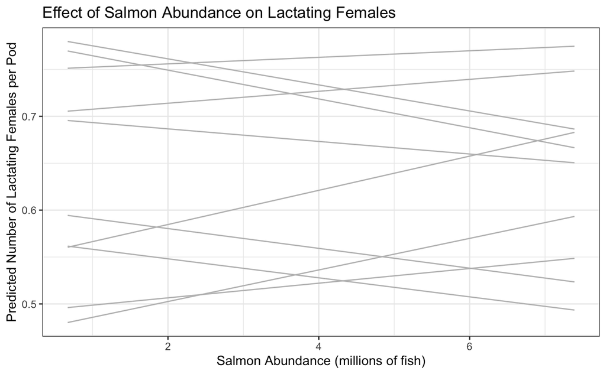

```r
# create variables to save the lines
salmon_lines <- NULL
pod_lines <- NULL

# Create lines where one fixed effect is constant using the slopes and
# intercepts from the models.

for (i in 1:length(result[[3]])){
  # Keeping pod size constant
  lines1 <- as.data.frame(cbind(salmons = salmons)) %>%
    mutate(lact_prediction = result[[3]][i]+
             result[[1]][i]*salmons)
  lines1 <- cbind(lines1, index_model = i)
  salmon_lines <- rbind(salmon_lines, lines1)

  # Keeping salmon constant
  lines2 <- as.data.frame(cbind(pods = pods)) %>%
    mutate(lact_prediction = result[[3]][i]+
             result[[2]][i]*pods)
  lines2 <- cbind(lines2, index_model = i)
  pod_lines <- rbind(pod_lines, lines2)
}

# Generate plots with the models of salmon and pod effects on the predicted
# lactating females
as.data.frame(salmon_lines) %>%
  ggplot(aes(x = salmons, y = lact_prediction, group = index_model))+
  geom_line(color = "gray")+
  geom_line(aes(x = mean(salmons), y = mean(lact_prediction)), colour = "blue")+
  labs(x = "Salmon Abundance (millions of fish)",
       y ="Predicted Number of Lactating Females per Pod" ,
       title = "Effect of Salmon Abundance on Lactating Females")+
  theme_bw()
```

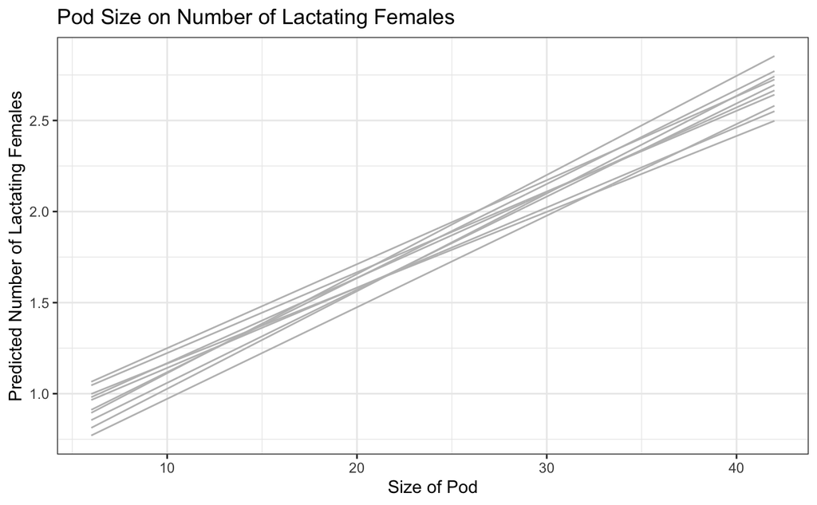

```r
as.data.frame(pod_lines) %>%
  ggplot(aes(x = pods, y = lact_prediction, group = index_model))+
  geom_line(color = "gray")+
  labs(x = "Size of Pod",
       y = "Predicted Number of Lactating Females",
       title = "Pod Size on Number of Lactating Females")+
  theme_bw()
```